# R Notebook

```r
library(lubridate)
library(tidyr)
library(reshape2) # Used to melt correlation matrix
library(data.table)
file.path <- "/Users/anandkumarpola/Documents/G3/RUTGERS/Stat581/Project/fires.csv"
```

```r
fire_data.df <- read.csv(file.path)
```

```r
head(fire_data.df)
```

|  | OBJECTID | FOD_ID | FPA_ID | SOURCE_SYSTEM_TYPE | SOURCE_SYSTEM | NWCG_REPORTING_AGENCY | NWCG_REPORTING_UNIT_ID | NWCG_REPORTING_UNIT_NAME | SOURCE_REPORTING_UNIT | SOURCE_REPORTING_UNIT_NAME | LOCAL_FIRE_REPORT_ID | LOCAL_INCIDENT_ID | FIRE_CODE | FIRE_NAME | ICS_209_INCIDENT_NUMBER | ICS_209_NAME | MTBS_ID | MTBS_FIRE_NAME | COMPLEX_NAME | FIRE_YEAR | DISCOVERY_DATE | DISCOVERY_DOY | DISCOVERY_TIME | STAT_CAUSE_CODE | STAT_CAUSE_DESCR | CONT_DATE | CONT_DOY | CONT_TIME | FIRE_SIZE | … |
| --- | --- | --- | --- | --- | --- | --- | --- | --- | --- | --- | --- | --- | --- | --- | --- | --- | --- | --- | --- | --- | --- | --- | --- | --- | --- | --- | --- | --- | --- | --- |
| 1 | 1 | 1 | FS-1418826 | FED | FS-FIRESTAT | FS | USCAPNF | Plumas National Forest | 0511 | Plumas National Forest | 1 | PNF-47 | BJ8K | FOUNTAIN |  |  |  |  |  | 2005 | 2453404 | 33 | 1300 | 9 | Miscellaneous | 2453404 | 33 | 1730 | 0.10 | … |
| 2 | 2 | 2 | FS-1418827 | FED | FS-FIRESTAT | FS | USCAENF | Eldorado National Forest | 0503 | Eldorado National Forest | 13 | 13 | AAC0 | PIGEON |  |  |  |  |  | 2004 | 2453138 | 133 | 845 | 1 | Lightning | 2453138 | 133 | 1530 | 0.25 | … |
| 3 | 3 | 3 | FS-1418835 | FED | FS-FIRESTAT | FS | USCAENF | Eldorado National Forest | 0503 | Eldorado National Forest | 27 | 021 | A32W | SLACK |  |  |  |  |  | 2004 | 2453156 | 152 | 1921 | 5 | Debris Burning | 2453156 | 152 | 2024 | 0.10 | … |
| 4 | 4 | 4 | FS-1418845 | FED | FS-FIRESTAT | FS | USCAENF | Eldorado National Forest | 0503 | Eldorado National Forest | 43 | 6 |  | DEER |  |  |  |  |  | 2004 | 2453184 | 180 | 1600 | 1 | Lightning | 2453190 | 185 | 1400 | 0.10 | … |
| 5 | 5 | 5 | FS-1418847 | FED | FS-FIRESTAT | FS | USCAENF | Eldorado National Forest | 0503 | Eldorado National Forest | 44 | 7 |  | STEVENOT |  |  |  |  |  | 2004 | 2453184 | 180 | 1600 | 1 | Lightning | 2453190 | 185 | 1200 | 0.10 | … |
| 6 | 6 | 6 | FS-1418849 | FED | FS-FIRESTAT | FS | USCAENF | Eldorado National Forest | 0503 | Eldorado National Forest | 54 | 8 |  | HIDDEN |  |  |  |  |  | 2004 | 2453186 | 182 | 1800 | 1 | Lightning | 2453188 | 183 | 1600 | 0.10 | … |

```r
tail(fire_data.df)
```

|  | OBJECTID | FOD_ID | FPA_ID | SOURCE_SYSTEM_TYPE | SOURCE_SYSTEM | NWCG_REPORTING_AGENCY | NWCG_REPORTING_UNIT_ID | NWCG_REPORTING_UNIT_NAME | SOURCE_REPORTING_UNIT | SOURCE_REPORTING_UNIT_NAME | LOCAL_FIRE_REPORT_ID | LOCAL_INCIDENT_ID | FIRE_CODE | FIRE_NAME | ICS_209_INCIDENT_NUMBER | ICS_209_NAME | MTBS_ID | MTBS_FIRE_NAME | COMPLEX_NAME | FIRE_YEAR | DISCOVERY_DATE | DISCOVERY_DOY | DISCOVERY_TIME | STAT_CAUSE_CODE | STAT_CAUSE_DESCR | CONT_DATE | CONT_DOY | CONT_TIME | FIRE_SIZE | … |
| --- | --- | --- | --- | --- | --- | --- | --- | --- | --- | --- | --- | --- | --- | --- | --- | --- | --- | --- | --- | --- | --- | --- | --- | --- | --- | --- | --- | --- | --- | --- |
| 1880464 | 1880464 | 300348377 | 2015CAIRS29218079 | NONFED | ST-CACDF | ST/C&L | USCATCU | Tuolumne-Calaveras Unit | CATCU | Tuolumne-Calaveras Unit | 570462 | 000380 |  |  |  |  |  |  |  | 2015 | 2457310 | 287 | 2309 | 13 | Missing/Undefined | NA | NA | NA | 2.0 | … |
| 1880465 | 1880465 | 300348399 | 2015CAIRS26733926 | NONFED | ST-CACDF | ST/C&L | USCABDU | San Bernardino Unit | CABDU | CDF - San Bernardino Unit | 535436 | 003225 |  | BARKER BL BIG_BEAR_LAKE_ |  |  |  |  |  | 2015 | 2457096 | 73 | 2128 | 9 | Miscellaneous | NA | NA | NA | 0.1 | … |
| 1880466 | f_table_name | f_geometry_column | geometry_type | coord_dimension | srid | spatial_index_enabled |  |  |  |  |  |  |  |  |  |  |  |  |  | NA | NA | NA | NA | NA |  | NA | NA | NA | NA | … |
| 1880467 | fires | shape | 1 | 2 | 4269 | 1 |  |  |  |  |  |  |  |  |  |  |  |  |  | NA | NA | NA | NA | NA |  | NA | NA | NA | NA | … |
| 1880468 | f_table_name | f_geometry_column | geometry_type | coord_dimension | srid | spatial_index_enabled |  |  |  |  |  |  |  |  |  |  |  |  |  | NA | NA | NA | NA | NA |  | NA | NA | NA | NA | … |
| 1880469 | fires | shape | 1 | 2 | 4269 | 1 |  |  |  |  |  |  |  |  |  |  |  |  |  | NA | NA | NA | NA | NA |  | NA | NA | NA | NA | … |

```r
summary(fire_data.df)
```

```
##    OBJECTID            FOD_ID             FPA_ID          SOURCE_SYSTEM_TYPE
##  Length:1880469     Length:1880469     Length:1880469     Length:1880469
##  Class :character   Class :character   Class :character   Class :character
##  Mode  :character   Mode  :character   Mode  :character   Mode  :character
##
##
##
##
##  SOURCE_SYSTEM      NWCG_REPORTING_AGENCY NWCG_REPORTING_UNIT_ID
##  Length:1880469     Length:1880469        Length:1880469
##  Class :character   Class :character      Class :character
##  Mode  :character   Mode  :character      Mode  :character
##
##
##
##
##  NWCG_REPORTING_UNIT_NAME SOURCE_REPORTING_UNIT SOURCE_REPORTING_UNIT_NAME
##  Length:1880469           Length:1880469        Length:1880469
##  Class :character         Class :character      Class :character
##  Mode  :character         Mode  :character      Mode  :character
##
##
##
##
##  LOCAL_FIRE_REPORT_ID LOCAL_INCIDENT_ID   FIRE_CODE          FIRE_NAME
##  Length:1880469       Length:1880469     Length:1880469     Length:1880469
##  Class :character     Class :character   Class :character   Class :character
##  Mode  :character     Mode  :character   Mode  :character   Mode  :character
##
##
##
##
##  ICS_209_INCIDENT_NUMBER ICS_209_NAME         MTBS_ID
##  Length:1880469          Length:1880469     Length:1880469
##  Class :character        Class :character   Class :character
##  Mode  :character        Mode  :character   Mode  :character
##
##
##
##
```

[output cut: 33 more lines]

```
##  Length:1880469     Length:1880469     Length:1880469     Min.   :  1.0
##  Class :character   Class :character   Class :character   1st Qu.: 29.0
##  Mode  :character   Mode  :character   Mode  :character   Median : 67.0
##                                                           Mean   : 95.8
##                                                           3rd Qu.:121.0
##                                                           Max.   :810.0
##                                                           NA's   :678152
##   FIPS_NAME          Shape
##  Length:1880469     Mode:logical
##  Class :character   NA's:1880469
##  Mode  :character
##
##
##
##
```

```r
print(paste("Data Available from ", range(fire_data.df$FIRE_YEAR, na.rm = TRUE)[1], " to ", range(fire_data.df$FIRE_YEAR, na.rm = TRUE)[2]))
```

```
## [1] "Data Available from  1992  to  2015"
```

```r
print(paste("That's ", range(fire_data.df$FIRE_YEAR, na.rm = TRUE)[2] - range(fire_data.df$FIRE_YEAR, na.rm = TRUE)[1], " years."))
```

```
## [1] "That's  23  years."
```

Explore Dates

```r
print("Head")
```

```
## [1] "Head"
```

```r
head(fire_data.df$DISCOVERY_DATE)
```

```
## [1] 2453404 2453138 2453156 2453184 2453184 2453186
```

```r
print("Tail")
```

```
## [1] "Tail"
```

```r
tail(fire_data.df$DISCOVERY_DATE)
```

```
## [1] 2457310 2457096      NA      NA      NA      NA
```

```r
print("Summary")
```

```
## [1] "Summary"
```

```r
summary(fire_data.df$DISCOVERY_DATE)
```

```
##    Min. 1st Qu.  Median    Mean 3rd Qu.    Max.    NA's
## 2448622 2451084 2453178 2453064 2455036 2457388       4
```

```r
"These are Julian dates. We need dates on a Gregorian calendar."
```

```
## [1] "These are Julian dates. We need dates on a Gregorian calendar."
```

Preprocessing Convert Dates to Gregorian Dates

```r
julian_origin <- ymd("0000-11-23") - years(4713)
Gregorian_dates <- as.Date(fire_data.df$DISCOVERY_DATE, origin = julian_origin)
head(Gregorian_dates)
```

```
## [1] "2005-01-31" "2004-05-10" "2004-05-29" "2004-06-26" "2004-06-26"
## [6] "2004-06-28"
```

```r
tail(Gregorian_dates)
```

```
## [1] "2015-10-12" "2015-03-12" NA           NA           NA
## [6] NA
```

```r
fire_data.df$DISCOVERY_DATE <- Gregorian_dates
```

```r
tail(fire_data.df$LATITUDE)
```

```
## [1] 37.67223 34.26322       NA       NA       NA       NA
```

```r
tail(fire_data.df$LONGITUDE)
```

```
## [1] -120.8984 -116.8310        NA        NA        NA        NA
```

```r
tail(fire_data.df$FIRE_SIZE)
```

```
## [1] 2.0 0.1  NA  NA  NA  NA
```

Notice that no information about coordinates, time, or size exists for the last four fires. Let’s drop them.

```r
fire_data.df <- fire_data.df[!is.na(fire_data.df$DISCOVERY_DATE),]
```

```r
tail(fire_data.df$DISCOVERY_DATE)
```

```
## [1] "2015-05-26" "2015-09-24" "2015-10-03" "2015-04-30" "2015-10-12"
## [6] "2015-03-12"
```

VISUALIZE ANNUAL

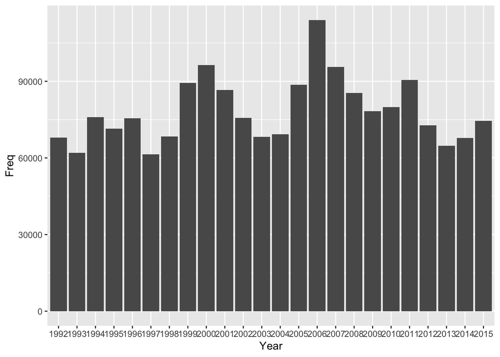

```r
library("ggplot2")
Annual_freq <- data.frame(table(fire_data.df$FIRE_YEAR))
colnames(Annual_freq) <- c("Year", "Freq")

# Annual_freq.lm <- lm(Freq ~ Year, Annual_freq)

# Annual_freq.lm

plot <-ggplot(data = Annual_freq, aes(x = Year, y = Freq)) +
      geom_bar(stat="identity")
#       geom_abline(slope = coef(Annual_freq.lm)[["Year"]],
#               intercept = coef(Annual_freq.lm)[["(Intercept)"]])
print(plot)
```

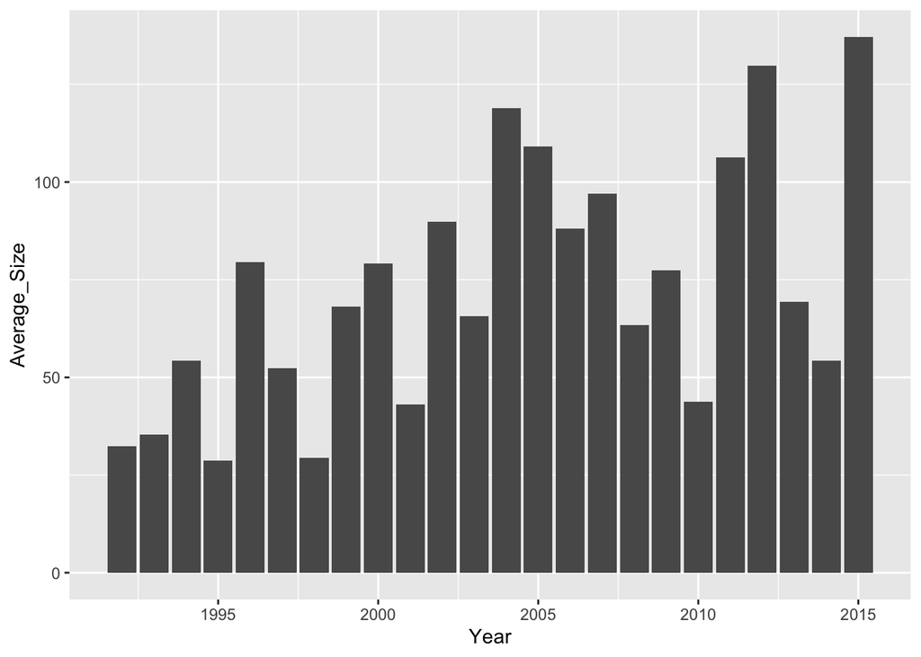

```r
Annual_Avg_size <- aggregate(fire_data.df$FIRE_SIZE, by = list(fire_data.df$FIRE_YEAR), FUN = mean)
colnames(Annual_Avg_size) <- c("Year", "Average_Size")
plot <-ggplot(data = Annual_Avg_size, aes(x = Year, y = Average_Size)) +
      geom_bar(stat="identity")
print(plot)
```

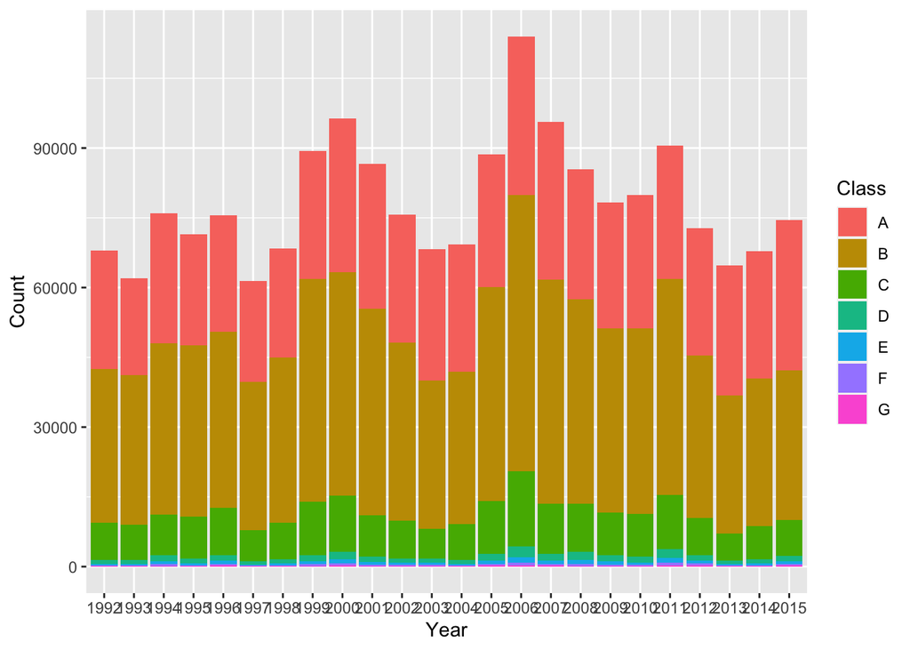

```r
class_table <- data.frame(table(fire_data.df$FIRE_YEAR, fire_data.df$FIRE_SIZE_CLASS))
names(class_table) <- c("Year", "Class", "Count")
plot <- ggplot(data = class_table, aes(x = Year, y = Count, fill = Class)) +
      geom_bar(stat = "identity")
print(plot)
```

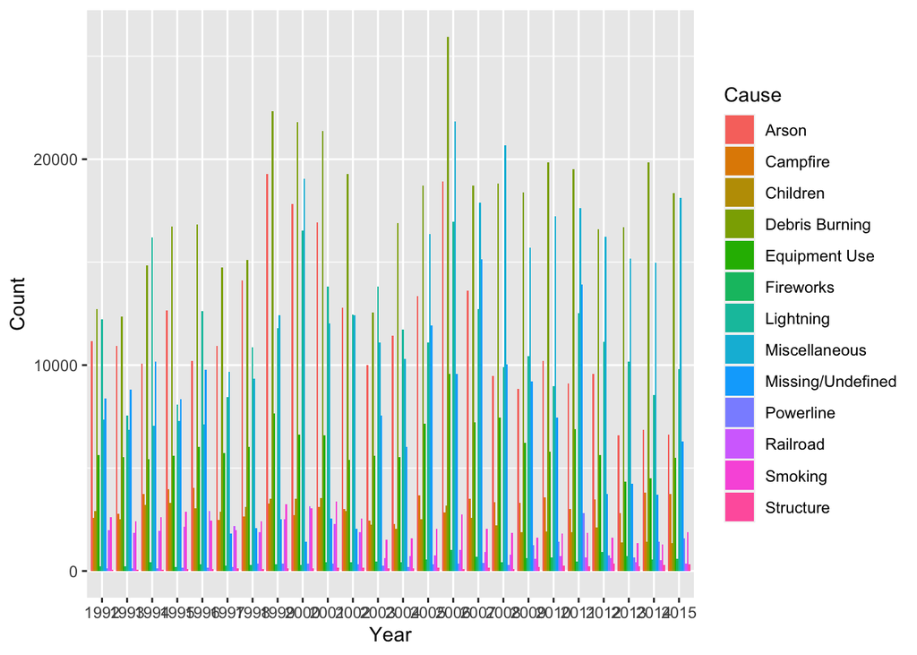

```r
cause_table <- data.frame(table(fire_data.df$FIRE_YEAR, fire_data.df$STAT_CAUSE_DESCR))
names(cause_table) <- c("Year", "Cause", "Count")
plot <- ggplot(data = cause_table, aes(x = Year, y = Count, fill = Cause)) +
      geom_bar(stat = "identity", position = "dodge")
print(plot)
```

MONTHLY

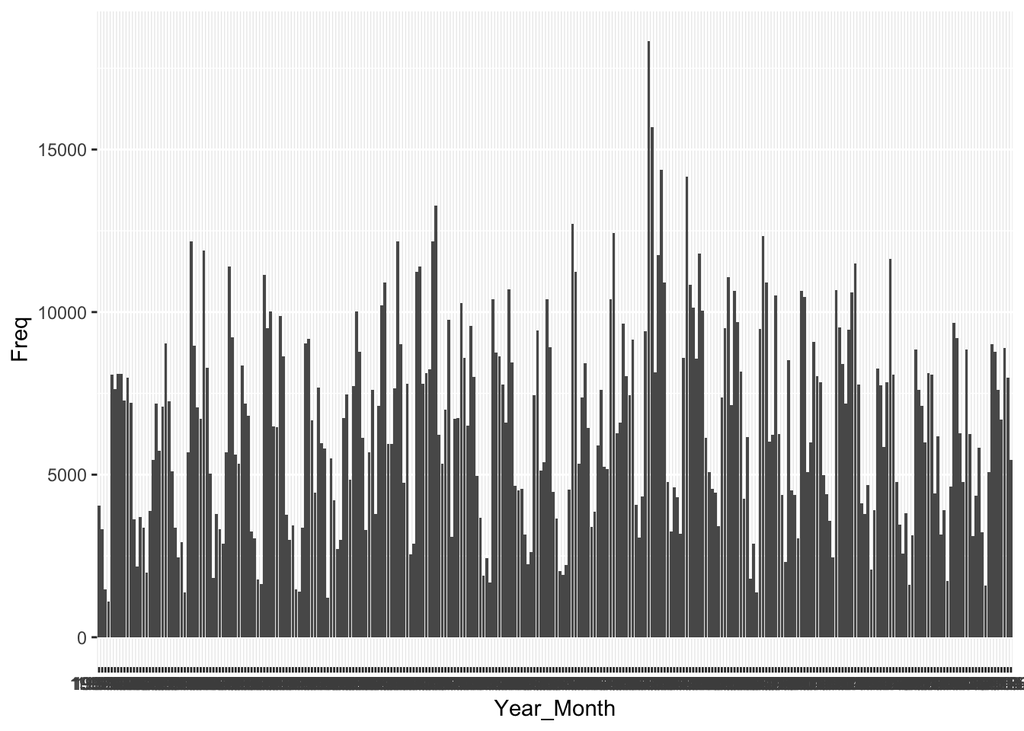

```r
library(ggplot2)
fire_data.df$MONTH <- month(fire_data.df$DISCOVERY_DATE)

fire_data.df$MONTH <- paste(fire_data.df$FIRE_YEAR, fire_data.df$MONTH, sep = '-')

monthly_freq <- data.frame(table(fire_data.df$MONTH))
colnames(monthly_freq) <- c("Year_Month", "Freq")

# Annual_freq.lm <- lm(Freq ~ Year, Annual_freq)

# Annual_freq.lm

plot <-ggplot(data = monthly_freq, aes(x = Year_Month, y = Freq)) +
       geom_bar(stat="identity")
print(plot)
```

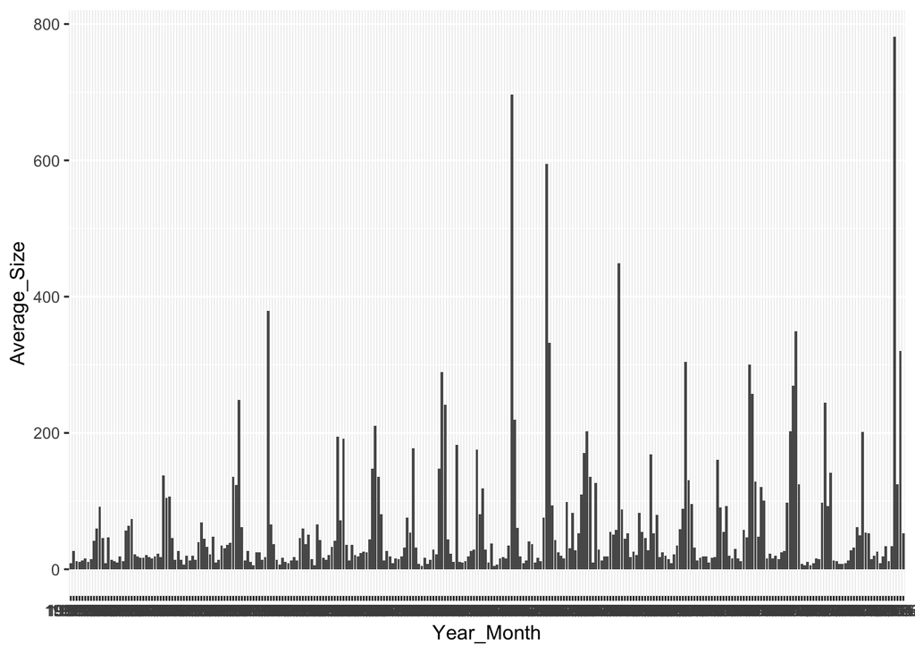

```r
Monthly_Avg_size <- aggregate(fire_data.df$FIRE_SIZE, by = list(fire_data.df$MONTH), FUN = mean)
colnames(Monthly_Avg_size) <- c("Year_Month", "Average_Size")
plot <-ggplot(data = Monthly_Avg_size, aes(x = Year_Month, y = Average_Size)) +
       geom_bar(stat="identity")
print(plot)
```

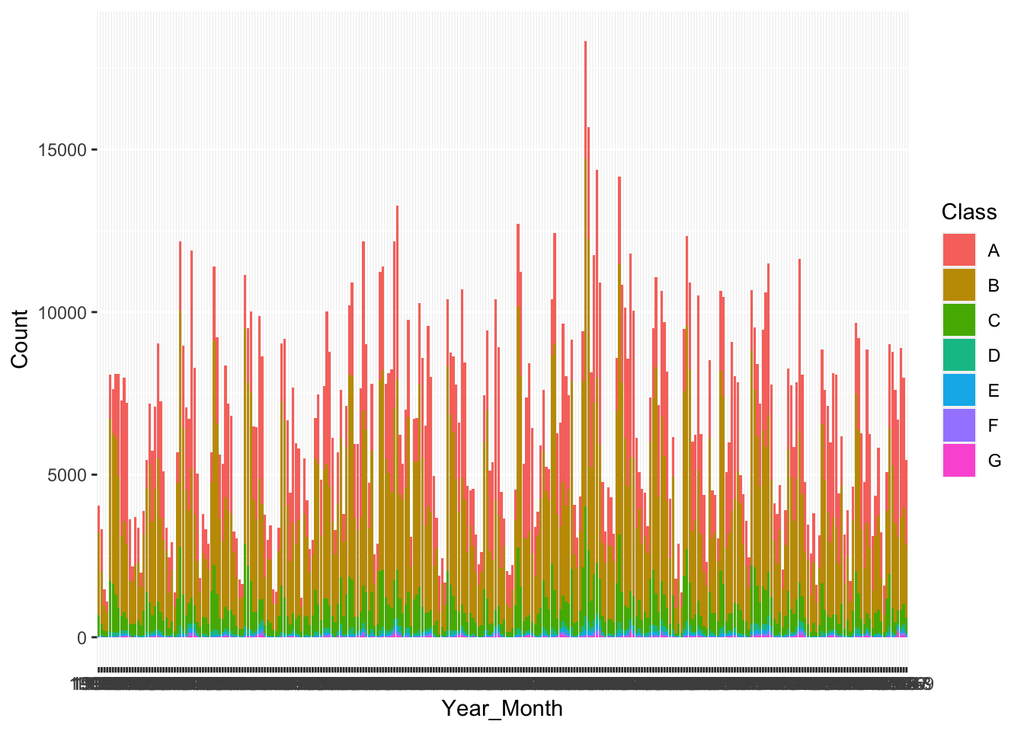

```r
class_table <- data.frame(table(fire_data.df$MONTH, fire_data.df$FIRE_SIZE_CLASS))
names(class_table) <- c("Year_Month", "Class", "Count")
plot <- ggplot(data = class_table, aes(x = Year_Month, y = Count, fill = Class)) +
      geom_bar(stat = "identity")
print(plot)
```

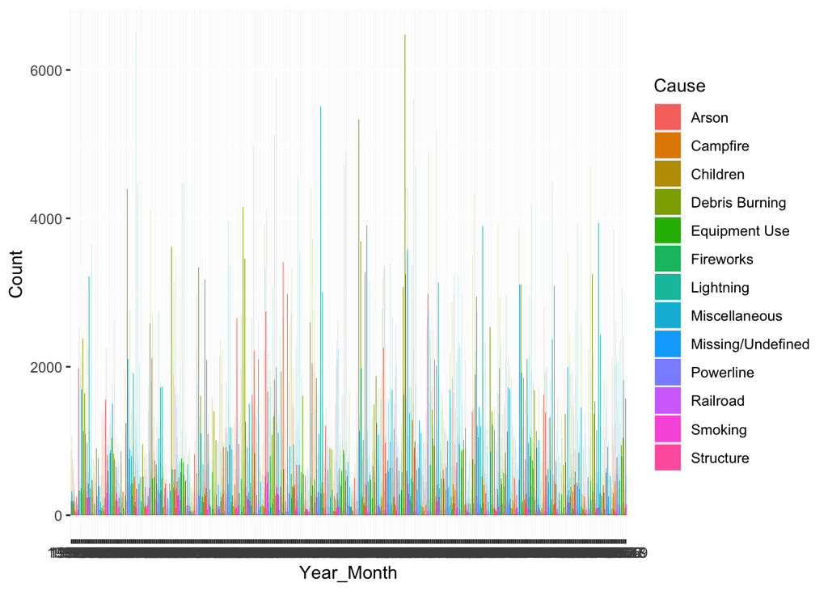

```r
cause_table <- data.frame(table(fire_data.df$MONTH, fire_data.df$STAT_CAUSE_DESCR))
names(cause_table) <- c("Year_Month", "Cause", "Count")
plot <- ggplot(data = cause_table, aes(x = Year_Month, y = Count, fill = Cause)) +
      geom_bar(stat = "identity", position = "dodge")
print(plot)
```

```r
filepath <- "/Users/anandkumarpola/Documents/G3/RUTGERS/Stat581/Project/climate_change.csv"
climate_data.df <- read.csv(filepath)
```

```r
head(climate_data.df)
```

|  | Year | Month | MEI | CO2 | CH4 | N2O | CFC.11 | CFC.12 | TSI | Aerosols | Temp |
| --- | --- | --- | --- | --- | --- | --- | --- | --- | --- | --- | --- |
| 1 | 1983 | 5 | 2.556 | 345.96 | 1638.59 | 303.677 | 191.324 | 350.113 | 1366.102 | 0.0863 | 0.109 |
| 2 | 1983 | 6 | 2.167 | 345.52 | 1633.71 | 303.746 | 192.057 | 351.848 | 1366.121 | 0.0794 | 0.118 |
| 3 | 1983 | 7 | 1.741 | 344.15 | 1633.22 | 303.795 | 192.818 | 353.725 | 1366.285 | 0.0731 | 0.137 |
| 4 | 1983 | 8 | 1.130 | 342.25 | 1631.35 | 303.839 | 193.602 | 355.633 | 1366.420 | 0.0673 | 0.176 |
| 5 | 1983 | 9 | 0.428 | 340.17 | 1648.40 | 303.901 | 194.392 | 357.465 | 1366.234 | 0.0619 | 0.149 |
| 6 | 1983 | 10 | 0.002 | 340.30 | 1663.79 | 303.970 | 195.171 | 359.174 | 1366.059 | 0.0569 | 0.093 |

```r
tail(climate_data.df)
```

|  | Year | Month | MEI | CO2 | CH4 | N2O | CFC.11 | CFC.12 | TSI | Aerosols | Temp |
| --- | --- | --- | --- | --- | --- | --- | --- | --- | --- | --- | --- |
| 303 | 2008 | 7 | 0.003 | 386.42 | 1782.93 | 321.372 | 244.434 | 535.026 | 1365.672 | 0.0033 | 0.406 |
| 304 | 2008 | 8 | -0.266 | 384.15 | 1779.88 | 321.405 | 244.200 | 535.072 | 1365.657 | 0.0036 | 0.407 |
| 305 | 2008 | 9 | -0.643 | 383.09 | 1795.08 | 321.529 | 244.083 | 535.048 | 1365.665 | 0.0043 | 0.378 |
| 306 | 2008 | 10 | -0.780 | 382.99 | 1814.18 | 321.796 | 244.080 | 534.927 | 1365.676 | 0.0046 | 0.440 |
| 307 | 2008 | 11 | -0.621 | 384.13 | 1812.37 | 322.013 | 244.225 | 534.906 | 1365.707 | 0.0048 | 0.394 |
| 308 | 2008 | 12 | -0.666 | 385.56 | 1812.88 | 322.182 | 244.204 | 535.005 | 1365.693 | 0.0046 | 0.330 |

```r
summary(climate_data.df)
```

```
##       Year          Month             MEI               CO2
##  Min.   :1983   Min.   : 1.000   Min.   :-1.6350   Min.   :340.2
##  1st Qu.:1989   1st Qu.: 4.000   1st Qu.:-0.3987   1st Qu.:353.0
##  Median :1996   Median : 7.000   Median : 0.2375   Median :361.7
##  Mean   :1996   Mean   : 6.552   Mean   : 0.2756   Mean   :363.2
##  3rd Qu.:2002   3rd Qu.:10.000   3rd Qu.: 0.8305   3rd Qu.:373.5
##  Max.   :2008   Max.   :12.000   Max.   : 3.0010   Max.   :388.5
##       CH4            N2O            CFC.11          CFC.12           TSI
##  Min.   :1630   Min.   :303.7   Min.   :191.3   Min.   :350.1   Min.   :1365
##  1st Qu.:1722   1st Qu.:308.1   1st Qu.:246.3   1st Qu.:472.4   1st Qu.:1366
##  Median :1764   Median :311.5   Median :258.3   Median :528.4   Median :1366
##  Mean   :1750   Mean   :312.4   Mean   :252.0   Mean   :497.5   Mean   :1366
##  3rd Qu.:1787   3rd Qu.:317.0   3rd Qu.:267.0   3rd Qu.:540.5   3rd Qu.:1366
##  Max.   :1814   Max.   :322.2   Max.   :271.5   Max.   :543.8   Max.   :1367
##     Aerosols            Temp
##  Min.   :0.00160   Min.   :-0.2820
##  1st Qu.:0.00280   1st Qu.: 0.1217
##  Median :0.00575   Median : 0.2480
##  Mean   :0.01666   Mean   : 0.2568
##  3rd Qu.:0.01260   3rd Qu.: 0.4073
##  Max.   :0.14940   Max.   : 0.7390
```

Visualization

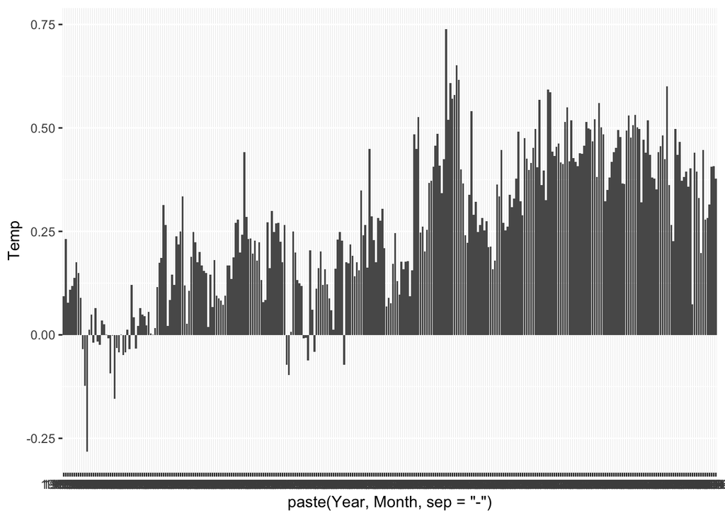

```r
plot <- ggplot(data = climate_data.df, aes(x = paste(Year, Month, sep = '-'), y = Temp)) +
      geom_bar(stat = "identity")
print(plot)
```

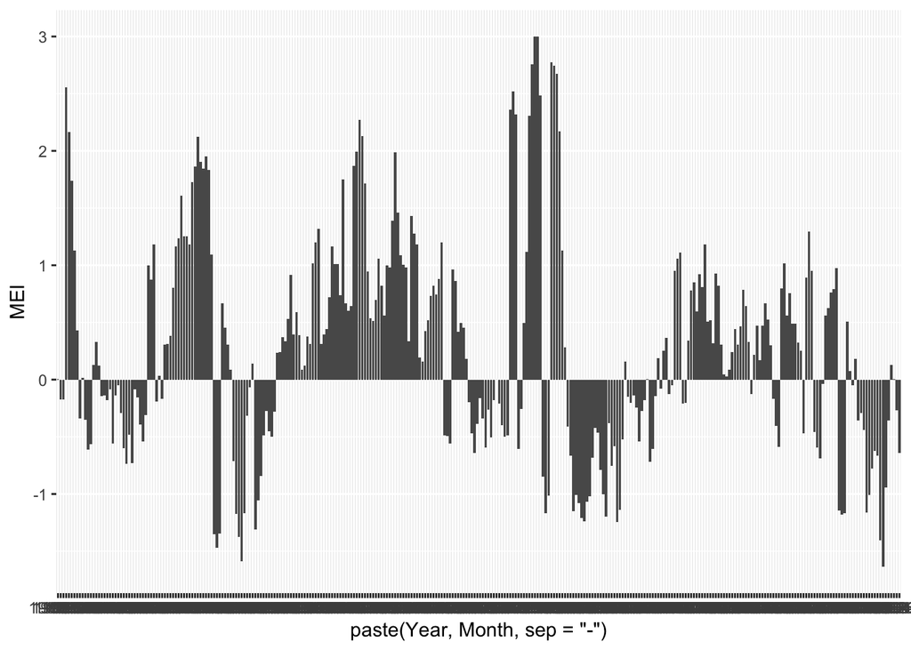

```r
plot <- ggplot(data = climate_data.df, aes(x = paste(Year, Month, sep = '-'), y = MEI)) +
      geom_bar(stat = "identity")
print(plot)
```

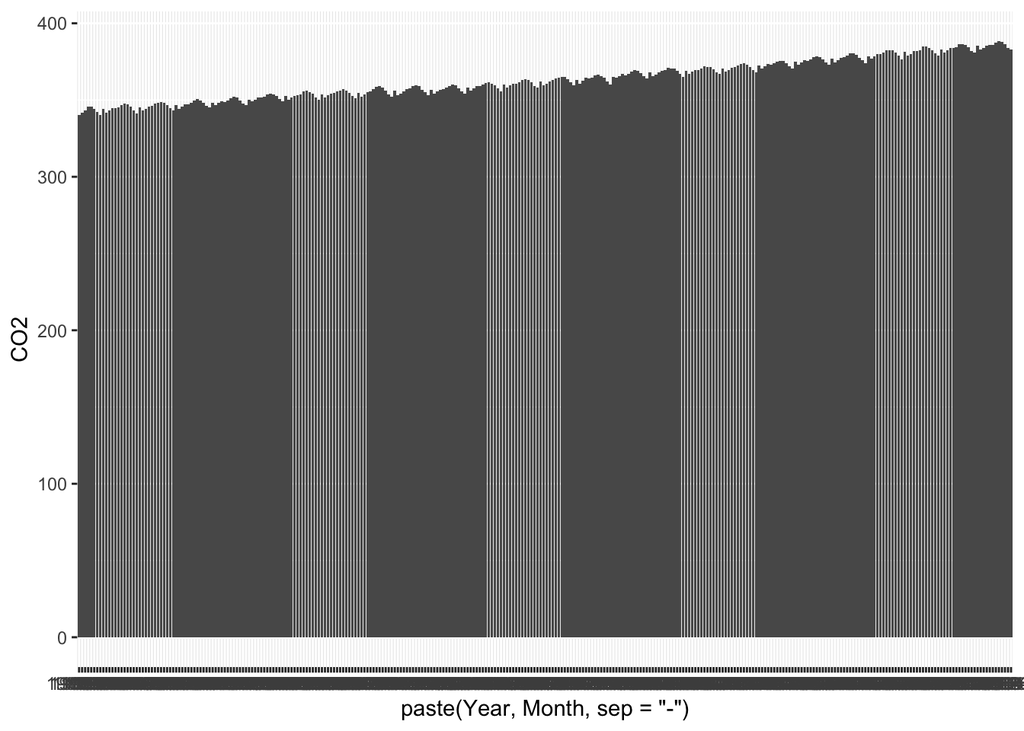

```r
plot <- ggplot(data = climate_data.df, aes(x = paste(Year, Month, sep = '-'), y = CO2)) +
      geom_bar(stat = "identity")
print(plot)
```

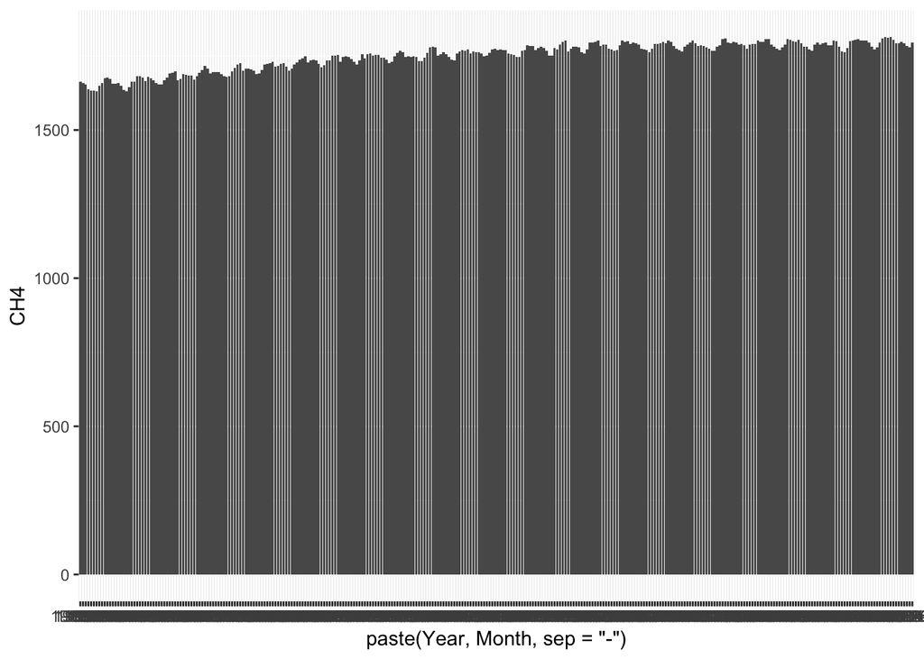

```r
plot <- ggplot(data = climate_data.df, aes(x = paste(Year, Month, sep = '-'), y = CH4)) +
      geom_bar(stat = "identity")
print(plot)
```

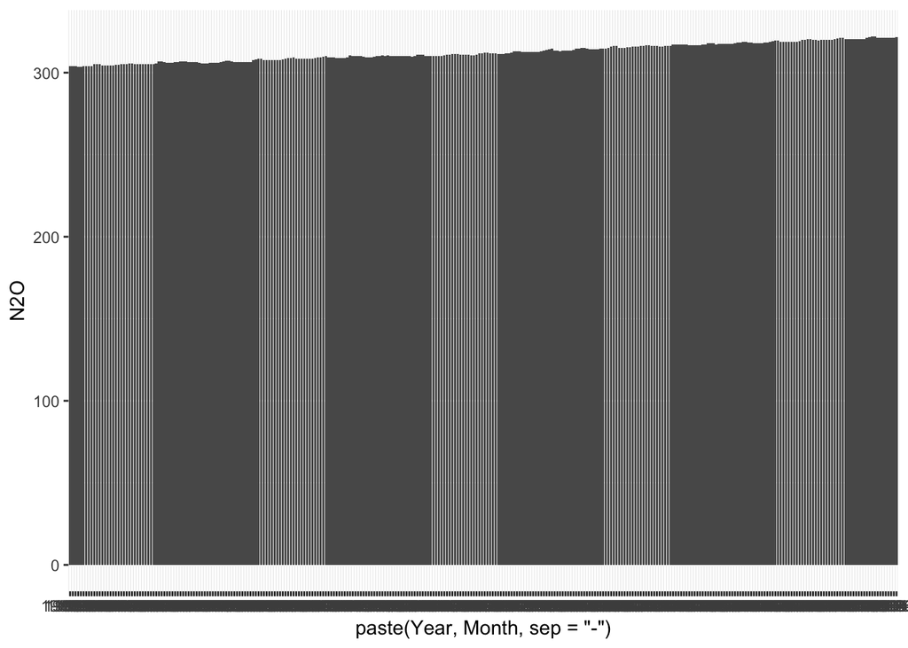

```r
plot <- ggplot(data = climate_data.df, aes(x = paste(Year, Month, sep = '-'), y = N2O)) +
      geom_bar(stat = "identity")
print(plot)
```

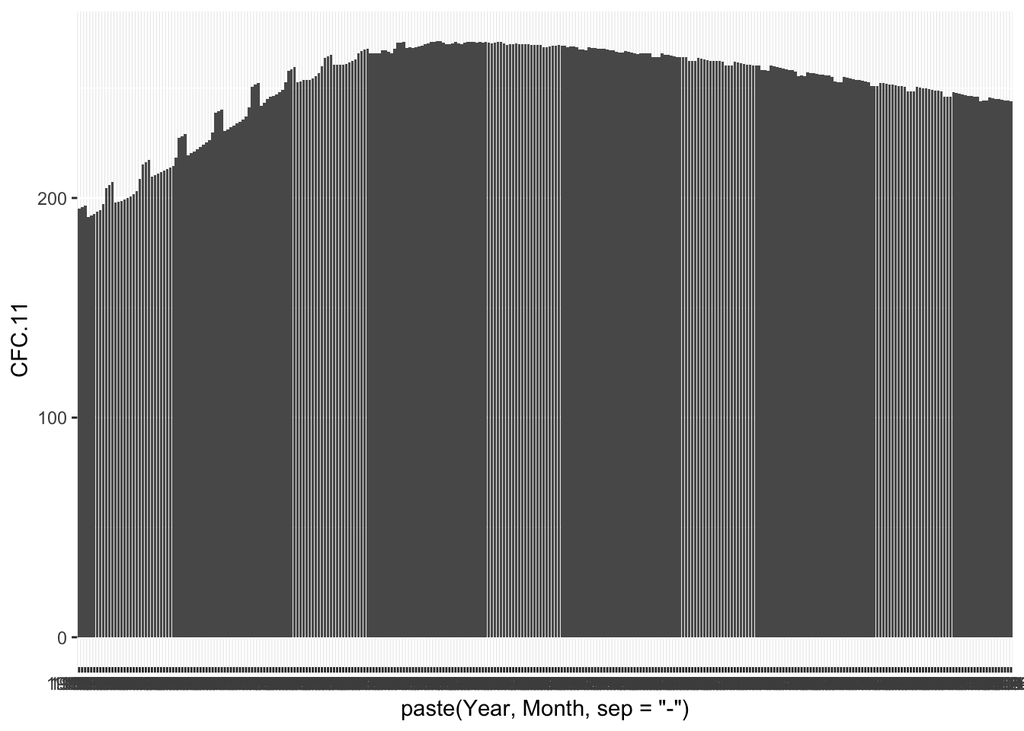

```r
plot <- ggplot(data = climate_data.df, aes(x = paste(Year, Month, sep = '-'), y = CFC.11)) +
      geom_bar(stat = "identity")
print(plot)
```

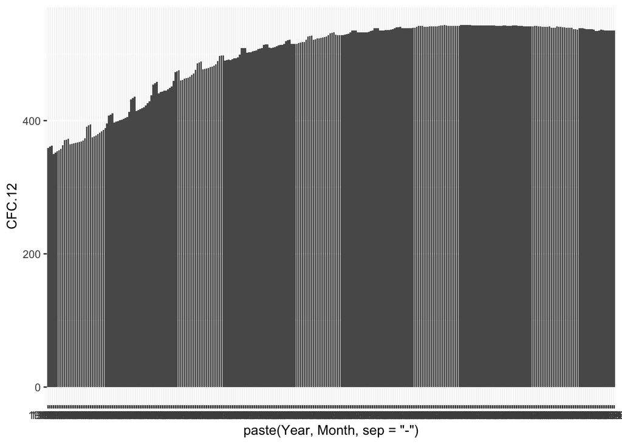

```r
plot <- ggplot(data = climate_data.df, aes(x = paste(Year, Month, sep = '-'), y = CFC.12)) +
      geom_bar(stat = "identity")
print(plot)
```

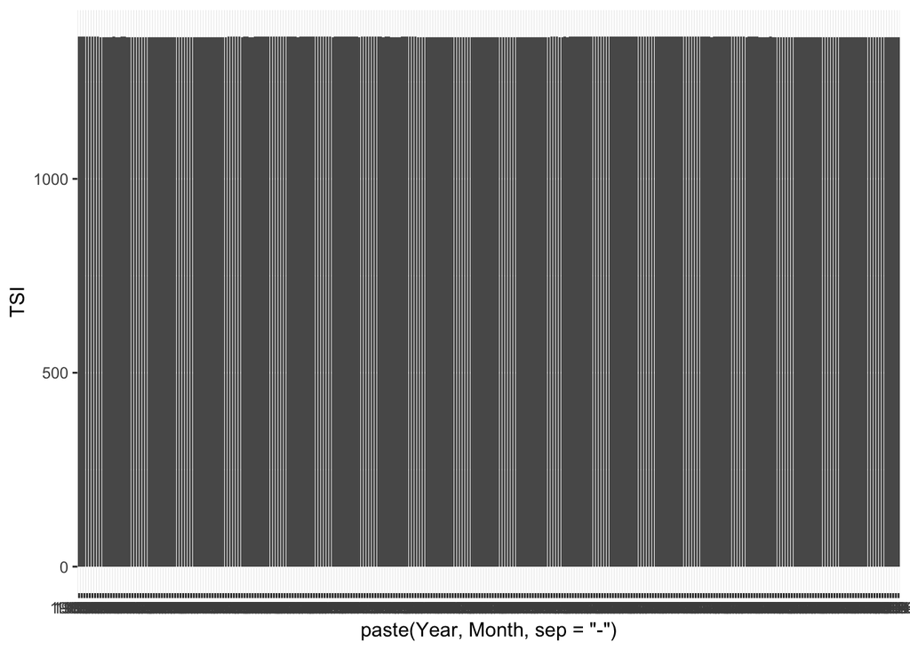

```r
plot <- ggplot(data = climate_data.df, aes(x = paste(Year, Month, sep = '-'), y = TSI)) +
      geom_bar(stat = "identity")
print(plot)
```

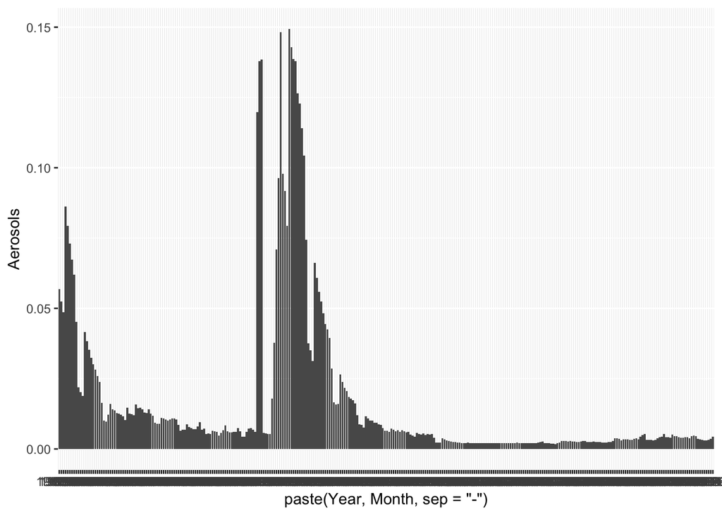

```r
plot <- ggplot(data = climate_data.df, aes(x = paste(Year, Month, sep = '-'), y = Aerosols)) +
      geom_bar(stat = "identity")
print(plot)
```

Scatterplots

```r
cor_mat <- round(cor(climate_data.df[-1:-2]), 2)
cor_mat
```

```
##            MEI   CO2   CH4   N2O CFC.11 CFC.12   TSI Aerosols  Temp
## MEI       1.00 -0.15 -0.11 -0.16   0.09  -0.04 -0.08     0.35  0.14
## CO2      -0.15  1.00  0.87  0.98   0.40   0.82  0.02    -0.37  0.75
## CH4      -0.11  0.87  1.00  0.89   0.71   0.96  0.15    -0.29  0.70
## N2O      -0.16  0.98  0.89  1.00   0.41   0.84  0.04    -0.35  0.74
## CFC.11    0.09  0.40  0.71  0.41   1.00   0.83  0.28    -0.03  0.38
## CFC.12   -0.04  0.82  0.96  0.84   0.83   1.00  0.19    -0.24  0.69
## TSI      -0.08  0.02  0.15  0.04   0.28   0.19  1.00     0.08  0.18
## Aerosols  0.35 -0.37 -0.29 -0.35  -0.03  -0.24  0.08     1.00 -0.39
## Temp      0.14  0.75  0.70  0.74   0.38   0.69  0.18    -0.39  1.00
```

```r
melted_cor_mat <- melt(cor_mat)
```

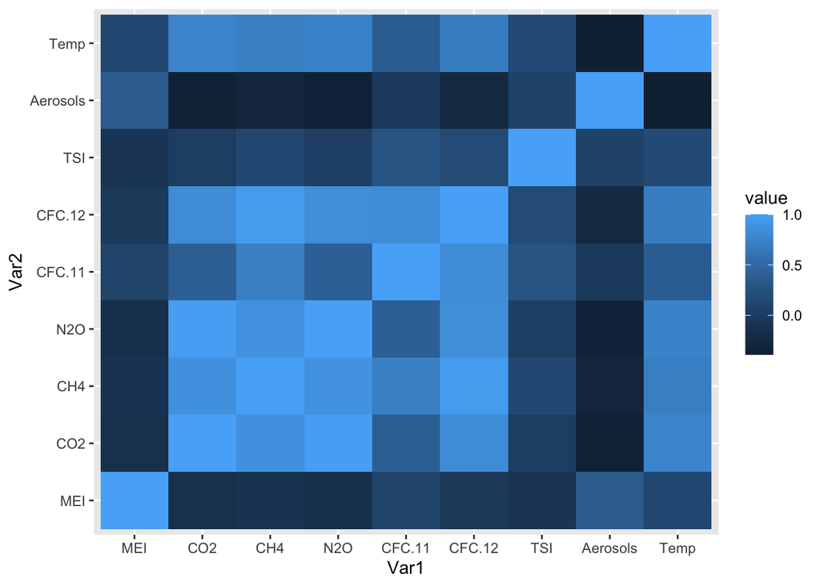

```r
ggplot(data = melted_cor_mat, aes(x = Var1, y = Var2, fill = value)) + geom_tile()
```

```r
monthly_fires_data <- cbind(monthly_freq, Monthly_Avg_size$Average_Size)
colnames(monthly_fires_data) <- c("Year_Month", "Freq", "Average_Size")
monthly_fires_data[monthly_fires_data$Year_Month %like% "2009", ][1,]
```

|  | Year_Month | Freq | Average_Size |
| --- | --- | --- | --- |
| 205 | 2009-1 | 6146 | 25.0771 |

```r
# joint_data.df <- cbind(climate_data.df, monthly_freq, Monthly_Avg_size$Average_Size)
```

The index of the first out-bound-month-year is 205. So, let’s drop all rows which satisfy the condition Index >= 205

```r
monthly_fires_data <- monthly_fires_data[1:204, ]
tail(monthly_fires_data)
```

|  | Year_Month | Freq | Average_Size |
| --- | --- | --- | --- |
| 199 | 2008-4 | 11078 | 45.99815 |
| 200 | 2008-5 | 7133 | 28.10814 |
| 201 | 2008-6 | 10647 | 168.08059 |
| 202 | 2008-7 | 9688 | 53.23399 |
| 203 | 2008-8 | 8161 | 79.44078 |
| 204 | 2008-9 | 4257 | 17.75445 |

```r
monthly_climate_data <- cbind(paste(climate_data.df$Year, climate_data.df$Month, sep = "-"), climate_data.df[,-1:-2])
names(monthly_climate_data)[1] <- c("Year_Month")
print(monthly_climate_data)
```

```
##     Year_Month    MEI    CO2     CH4     N2O  CFC.11  CFC.12      TSI Aerosols
## 1       1983-5  2.556 345.96 1638.59 303.677 191.324 350.113 1366.102   0.0863
## 2       1983-6  2.167 345.52 1633.71 303.746 192.057 351.848 1366.121   0.0794
## 3       1983-7  1.741 344.15 1633.22 303.795 192.818 353.725 1366.285   0.0731
## 4       1983-8  1.130 342.25 1631.35 303.839 193.602 355.633 1366.420   0.0673
## 5       1983-9  0.428 340.17 1648.40 303.901 194.392 357.465 1366.234   0.0619
## 6      1983-10  0.002 340.30 1663.79 303.970 195.171 359.174 1366.059   0.0569
## 7      1983-11 -0.176 341.53 1658.23 304.032 195.921 360.758 1366.107   0.0524
## 8      1983-12 -0.176 343.07 1654.31 304.082 196.609 362.174 1366.061   0.0486
## 9       1984-1 -0.339 344.05 1658.98 304.130 197.219 363.359 1365.426   0.0451
## 10      1984-2 -0.565 344.77 1656.48 304.194 197.759 364.296 1365.662   0.0416
## 11      1984-3  0.131 345.46 1655.77 304.285 198.249 365.044 1366.170   0.0383
## 12      1984-4  0.331 346.77 1657.68 304.389 198.723 365.692 1365.566   0.0352
## 13      1984-5  0.121 347.55 1649.33 304.489 199.233 366.317 1365.778   0.0324
## 14      1984-6 -0.142 346.98 1634.13 304.593 199.858 367.029 1366.096   0.0302
```

[output cut: 603 more lines]

```r
monthly_climate_data[monthly_climate_data$Year_Month %like% "1992", ][1,]
```

|  | Year_Month | MEI | CO2 | CH4 | N2O | CFC.11 | CFC.12 | TSI | Aerosols | Temp |
| --- | --- | --- | --- | --- | --- | --- | --- | --- | --- | --- |
| 105 | 1992-1 | 1.75 | 356.17 | 1755.57 | 310.48 | 268.05 | 499.467 | 1366.523 | 0.1483 | 0.266 |

Trim all rows up to 104

```r
monthly_climate_data <- monthly_climate_data[105:nrow(monthly_climate_data), ]
head(monthly_climate_data)
```

|  | Year_Month | MEI | CO2 | CH4 | N2O | CFC.11 | CFC.12 | TSI | Aerosols | Temp |
| --- | --- | --- | --- | --- | --- | --- | --- | --- | --- | --- |
| 105 | 1992-1 | 1.750 | 356.17 | 1755.57 | 310.480 | 268.050 | 499.467 | 1366.523 | 0.1483 | 0.266 |
| 106 | 1992-2 | 1.871 | 356.93 | 1750.02 | 310.128 | 268.274 | 501.644 | 1366.427 | 0.1494 | 0.250 |
| 107 | 1992-3 | 1.992 | 357.82 | 1752.39 | 309.690 | 268.477 | 502.436 | 1366.746 | 0.1428 | 0.199 |
| 108 | 1992-4 | 2.271 | 359.00 | 1753.24 | 309.508 | 268.387 | 502.811 | 1366.595 | 0.1386 | 0.132 |
| 109 | 1992-5 | 2.130 | 359.55 | 1744.48 | 309.383 | 268.650 | 504.226 | 1366.417 | 0.1379 | 0.125 |
| 110 | 1992-6 | 1.714 | 359.32 | 1743.30 | 309.392 | 269.014 | 505.101 | 1366.297 | 0.1265 | 0.118 |

```r
head(monthly_fires_data)
```

|  | Year_Month | Freq | Average_Size |
| --- | --- | --- | --- |
| 1 | 1992-1 | 4055 | 8.811354 |
| 2 | 1992-10 | 3324 | 27.157076 |
| 3 | 1992-11 | 1479 | 12.061420 |
| 4 | 1992-12 | 1088 | 10.542270 |
| 5 | 1992-2 | 8079 | 12.450995 |
| 6 | 1992-3 | 7635 | 15.896285 |

```r
head(monthly_climate_data)
```

|  | Year_Month | MEI | CO2 | CH4 | N2O | CFC.11 | CFC.12 | TSI | Aerosols | Temp |
| --- | --- | --- | --- | --- | --- | --- | --- | --- | --- | --- |
| 105 | 1992-1 | 1.750 | 356.17 | 1755.57 | 310.480 | 268.050 | 499.467 | 1366.523 | 0.1483 | 0.266 |
| 106 | 1992-2 | 1.871 | 356.93 | 1750.02 | 310.128 | 268.274 | 501.644 | 1366.427 | 0.1494 | 0.250 |
| 107 | 1992-3 | 1.992 | 357.82 | 1752.39 | 309.690 | 268.477 | 502.436 | 1366.746 | 0.1428 | 0.199 |
| 108 | 1992-4 | 2.271 | 359.00 | 1753.24 | 309.508 | 268.387 | 502.811 | 1366.595 | 0.1386 | 0.132 |
| 109 | 1992-5 | 2.130 | 359.55 | 1744.48 | 309.383 | 268.650 | 504.226 | 1366.417 | 0.1379 | 0.125 |
| 110 | 1992-6 | 1.714 | 359.32 | 1743.30 | 309.392 | 269.014 | 505.101 | 1366.297 | 0.1265 | 0.118 |

```r
monthly_fires_data$ID <- seq(1:nrow(monthly_fires_data))
```

```r
joint_monthly_data.df <- merge(monthly_climate_data, monthly_fires_data, by = "Year_Month")
```

```r
joint_monthly_data.df <- joint_monthly_data.df[order(joint_monthly_data.df$ID), ]
head(joint_monthly_data.df)
```

|  | Year_Month | MEI | CO2 | CH4 | N2O | CFC.11 | CFC.12 | TSI | Aerosols | Temp | Freq | Average_Size | ID |
| --- | --- | --- | --- | --- | --- | --- | --- | --- | --- | --- | --- | --- | --- |
| 1 | 1992-1 | 1.750 | 356.17 | 1755.57 | 310.480 | 268.050 | 499.467 | 1366.523 | 0.1483 | 0.266 | 4055 | 8.811354 | 1 |
| 2 | 1992-10 | 0.669 | 353.31 | 1740.76 | 310.252 | 270.765 | 508.614 | 1365.920 | 0.0978 | -0.072 | 3324 | 27.157076 | 2 |
| 3 | 1992-11 | 0.602 | 354.27 | 1755.29 | 310.216 | 270.886 | 508.737 | 1366.133 | 0.0918 | -0.097 | 1479 | 12.061420 | 3 |
| 4 | 1992-12 | 0.644 | 355.53 | 1758.32 | 310.293 | 271.057 | 509.265 | 1366.284 | 0.0793 | 0.007 | 1088 | 10.542270 | 4 |
| 5 | 1992-2 | 1.871 | 356.93 | 1750.02 | 310.128 | 268.274 | 501.644 | 1366.427 | 0.1494 | 0.250 | 8079 | 12.450995 | 5 |
| 6 | 1992-3 | 1.992 | 357.82 | 1752.39 | 309.690 | 268.477 | 502.436 | 1366.746 | 0.1428 | 0.199 | 7635 | 15.896285 | 6 |

```r
rownames(joint_monthly_data.df) <- 1:nrow(joint_monthly_data.df)    # Assign sequence to row names
joint_monthly_data.df <- joint_monthly_data.df[, 1:12]
```

```r
head(joint_monthly_data.df)
```

|  | Year_Month | MEI | CO2 | CH4 | N2O | CFC.11 | CFC.12 | TSI | Aerosols | Temp | Freq | Average_Size |
| --- | --- | --- | --- | --- | --- | --- | --- | --- | --- | --- | --- | --- |
| 1 | 1992-1 | 1.750 | 356.17 | 1755.57 | 310.480 | 268.050 | 499.467 | 1366.523 | 0.1483 | 0.266 | 4055 | 8.811354 |
| 2 | 1992-10 | 0.669 | 353.31 | 1740.76 | 310.252 | 270.765 | 508.614 | 1365.920 | 0.0978 | -0.072 | 3324 | 27.157076 |
| 3 | 1992-11 | 0.602 | 354.27 | 1755.29 | 310.216 | 270.886 | 508.737 | 1366.133 | 0.0918 | -0.097 | 1479 | 12.061420 |
| 4 | 1992-12 | 0.644 | 355.53 | 1758.32 | 310.293 | 271.057 | 509.265 | 1366.284 | 0.0793 | 0.007 | 1088 | 10.542270 |
| 5 | 1992-2 | 1.871 | 356.93 | 1750.02 | 310.128 | 268.274 | 501.644 | 1366.427 | 0.1494 | 0.250 | 8079 | 12.450995 |
| 6 | 1992-3 | 1.992 | 357.82 | 1752.39 | 309.690 | 268.477 | 502.436 | 1366.746 | 0.1428 | 0.199 | 7635 | 15.896285 |

Correlation Matrix

```r
cor_mat <- round(cor(joint_monthly_data.df[-1:-2]), 2)
cor_mat
```

```
##                CO2   CH4   N2O CFC.11 CFC.12   TSI Aerosols  Temp  Freq
## CO2           1.00  0.73  0.97  -0.96   0.73 -0.06    -0.51  0.60  0.30
## CH4           0.73  1.00  0.77  -0.68   0.76  0.12    -0.57  0.53 -0.06
## N2O           0.97  0.77  1.00  -0.98   0.76  0.00    -0.52  0.60  0.19
## CFC.11       -0.96 -0.68 -0.98   1.00  -0.62  0.11     0.38 -0.53 -0.21
## CFC.12        0.73  0.76  0.76  -0.62   1.00  0.22    -0.82  0.70  0.14
## TSI          -0.06  0.12  0.00   0.11   0.22  1.00     0.10  0.14  0.02
## Aerosols     -0.51 -0.57 -0.52   0.38  -0.82  0.10     1.00 -0.52 -0.09
## Temp          0.60  0.53  0.60  -0.53   0.70  0.14    -0.52  1.00  0.14
## Freq          0.30 -0.06  0.19  -0.21   0.14  0.02    -0.09  0.14  1.00
## Average_Size  0.21 -0.12  0.17  -0.19   0.15 -0.09    -0.12  0.09  0.25
##              Average_Size
## CO2                  0.21
## CH4                 -0.12
## N2O                  0.17
## CFC.11              -0.19
## CFC.12               0.15
## TSI                 -0.09
## Aerosols            -0.12
## Temp                 0.09
## Freq                 0.25
## Average_Size         1.00
```

```r
melted_cor_mat <- melt(cor_mat)
```

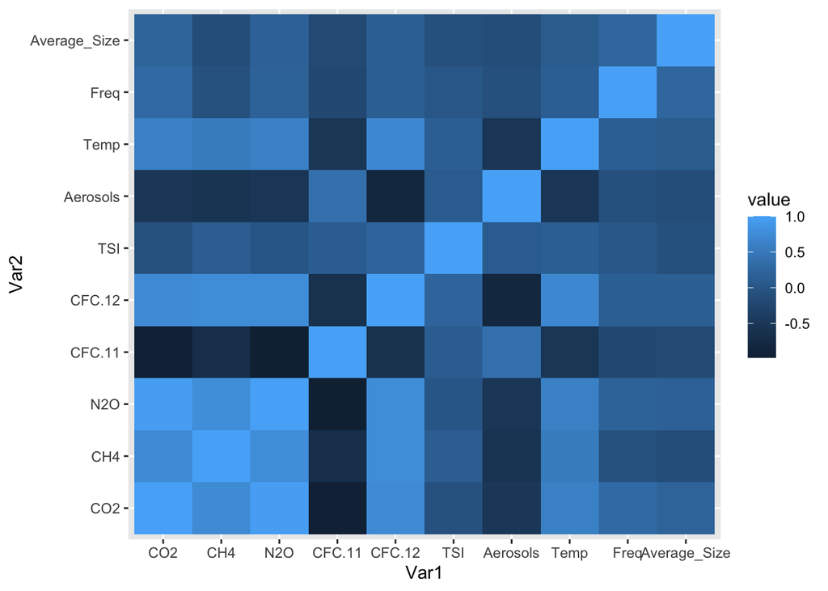

```r
ggplot(data = melted_cor_mat, aes(x = Var1, y = Var2, fill = value)) + geom_tile()
```

Geometric Plot - Plotting fires locations on a map

```r
options(warn = -1)
library(rworldmap)
```

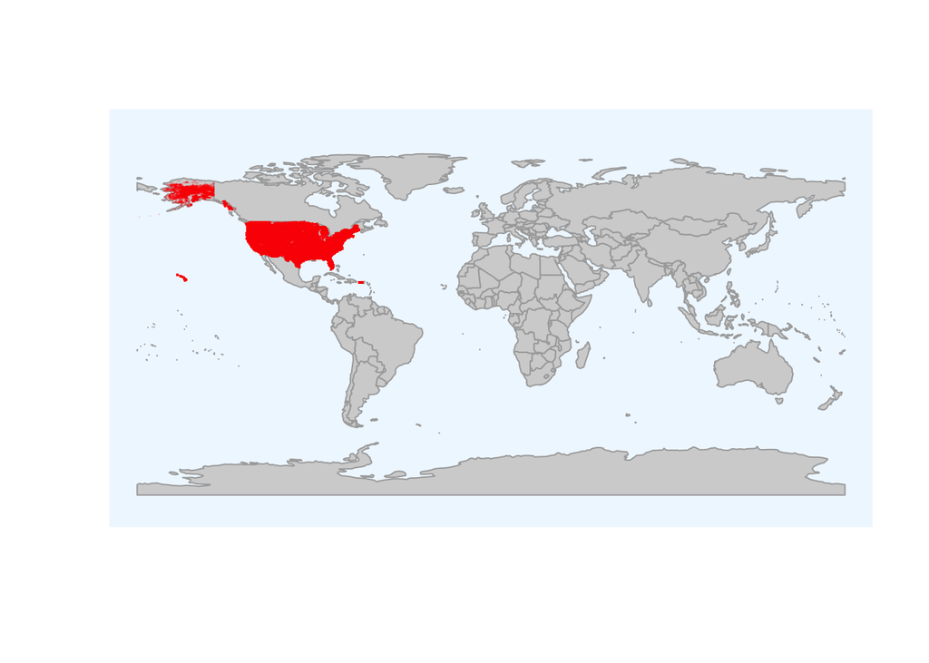

```r
worldmap <- getMap(resolution = "coarse")
plot(worldmap, col = "lightgrey",
     fill = T, border = "darkgray",
     xlim = c(-180, 180), ylim = c(-90, 90),
     bg = "aliceblue",
     asp = 1, wrap=c(-180,180))

points(fire_data.df$LONGITUDE, fire_data.df$LATITUDE,
       col = "red", cex = .01)
```

Linear Regression - Predicting #fires and average size of wild fire per month based on climatic conditions

```r
nrow(joint_monthly_data.df)
```

```
## [1] 204
```

```r
head(joint_monthly_data.df)
```

|  | Year_Month | MEI | CO2 | CH4 | N2O | CFC.11 | CFC.12 | TSI | Aerosols | Temp | Freq | Average_Size |
| --- | --- | --- | --- | --- | --- | --- | --- | --- | --- | --- | --- | --- |
| 1 | 1992-1 | 1.750 | 356.17 | 1755.57 | 310.480 | 268.050 | 499.467 | 1366.523 | 0.1483 | 0.266 | 4055 | 8.811354 |
| 2 | 1992-10 | 0.669 | 353.31 | 1740.76 | 310.252 | 270.765 | 508.614 | 1365.920 | 0.0978 | -0.072 | 3324 | 27.157076 |
| 3 | 1992-11 | 0.602 | 354.27 | 1755.29 | 310.216 | 270.886 | 508.737 | 1366.133 | 0.0918 | -0.097 | 1479 | 12.061420 |
| 4 | 1992-12 | 0.644 | 355.53 | 1758.32 | 310.293 | 271.057 | 509.265 | 1366.284 | 0.0793 | 0.007 | 1088 | 10.542270 |
| 5 | 1992-2 | 1.871 | 356.93 | 1750.02 | 310.128 | 268.274 | 501.644 | 1366.427 | 0.1494 | 0.250 | 8079 | 12.450995 |
| 6 | 1992-3 | 1.992 | 357.82 | 1752.39 | 309.690 | 268.477 | 502.436 | 1366.746 | 0.1428 | 0.199 | 7635 | 15.896285 |

```r
joint_monthly_data.df[10]
```

|  | Temp |
| --- | --- |
| 1 | 0.266 |
| 2 | -0.072 |
| 3 | -0.097 |
| 4 | 0.007 |
| 5 | 0.250 |
| 6 | 0.199 |
| 7 | 0.132 |
| 8 | 0.125 |
| 9 | 0.118 |
| 10 | -0.008 |

[output cut: 194 more lines]

We are checking the correlation between them, if the correlation is >0.8 for any two variables, only one among them is enough to include in linear regression

```r
round(cor(cbind(joint_monthly_data.df$Temp, joint_monthly_data.df$MEI,joint_monthly_data.df$CO2,joint_monthly_data.df$CH4, joint_monthly_data.df$N2O,joint_monthly_data.df$CFC.11)),2)
```

```
##       [,1]  [,2]  [,3]  [,4]  [,5]  [,6]
## [1,]  1.00  0.10  0.60  0.53  0.60 -0.53
## [2,]  0.10  1.00 -0.32 -0.40 -0.35  0.29
## [3,]  0.60 -0.32  1.00  0.73  0.97 -0.96
## [4,]  0.53 -0.40  0.73  1.00  0.77 -0.68
## [5,]  0.60 -0.35  0.97  0.77  1.00 -0.98
## [6,] -0.53  0.29 -0.96 -0.68 -0.98  1.00
```

Since CO2, N2O and CFC.11 are strongly related to each other, we can include only one among. Let’s consider only CO2 Hence we are using multiple linear regression on temp, CO2, MEI and CH4

The rule of thumb in regression is that there must be minimum 10 rows for each independent variable, i.e., in this case we need at least 40 observations for reasonably good prediction results. Our dataset contains 204 observations. Hence we can use this data for prediction.

Taking these columns into another data frame for easy processing

```r
train_data <- joint_monthly_data.df[,c("Temp","MEI","CO2","CH4","Freq","Average_Size")]
head(train_data)
```

|  | Temp | MEI | CO2 | CH4 | Freq | Average_Size |
| --- | --- | --- | --- | --- | --- | --- |
| 1 | 0.266 | 1.750 | 356.17 | 1755.57 | 4055 | 8.811354 |
| 2 | -0.072 | 0.669 | 353.31 | 1740.76 | 3324 | 27.157076 |
| 3 | -0.097 | 0.602 | 354.27 | 1755.29 | 1479 | 12.061420 |
| 4 | 0.007 | 0.644 | 355.53 | 1758.32 | 1088 | 10.542270 |
| 5 | 0.250 | 1.871 | 356.93 | 1750.02 | 8079 | 12.450995 |
| 6 | 0.199 | 1.992 | 357.82 | 1752.39 | 7635 | 15.896285 |

```r
Temp<-as.data.frame(train_data$Temp)
head(Temp)
```

|  | train_data$Temp |
| --- | --- |
| 1 | 0.266 |
| 2 | -0.072 |
| 3 | -0.097 |
| 4 | 0.007 |
| 5 | 0.250 |
| 6 | 0.199 |

Scatterplots should be produced for each independent with the dependent so see if the relationship is linear

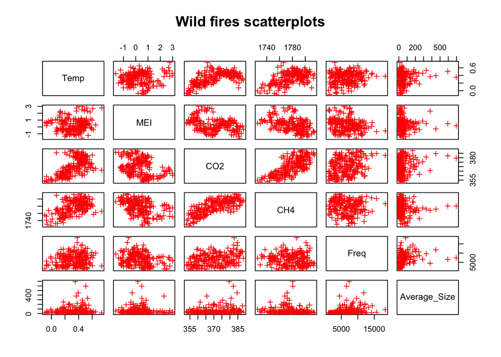

```r
pairs(train_data[,1:6],main='Wild fires scatterplots',col = "red",pch=3)
```

There are mostly no non-linear patterns between any pair of variables, (some do exist and we can see it’s affect in the summary of our model)

Fitting linear regression to predict freq

```r
#summary()
#reg<-lm(train_data$Freq~train_data$Temp+train_data$MEI,train_data$CO2,train_data$CH4)
reg <- lm(Freq~Temp+MEI+CO2+CH4, data = train_data)

summary(reg)
```

```
##
## Call:
## lm(formula = Freq ~ Temp + MEI + CO2 + CH4, data = train_data)
##
## Residuals:
##     Min      1Q  Median      3Q     Max
## -4346.6 -1979.5  -273.7  1556.0  9093.6
##
## Coefficients:
##              Estimate Std. Error t value Pr(>|t|)
## (Intercept) 144706.00   23796.96   6.081 6.01e-09 ***
## Temp          4068.89    1675.42   2.429    0.016 *
## MEI          -1061.09     240.35  -4.415 1.66e-05 ***
## CO2            208.45      32.20   6.474 7.30e-10 ***
## CH4           -121.67      15.31  -7.945 1.41e-13 ***
## ---
## Signif. codes:  0 '***' 0.001 '**' 0.01 '*' 0.05 '.' 0.1 ' ' 1
##
## Residual standard error: 2683 on 199 degrees of freedom
## Multiple R-squared:  0.316,  Adjusted R-squared:  0.3022
## F-statistic: 22.98 on 4 and 199 DF,  p-value: 1.258e-15
```

The last column contains the p-values for each of the independent variables. A p-value < 0.05, provides evidence that the coefficient is different to 0(*** = highly significant). We want it to be far away from zero as this would indicate we could reject the null hypothesis - that is, we could declare a relationship between Freq and independent variable exist. From the summary we can say that “MEI, CO2 & CH4” are all significant in predicting the freq of wildfires per month

The Estimate column in the coefficients table, gives us the coefficients for each independent variable in the regression model. Our model is Freq(y) = 144706.00 + 4068.89(Temp) - 1061.09(MEI) + 208.45(CO2) - 121.67(CH4)

HENCE WE CAN STATE THAT CLIMATIC CONDITIONS DO PLAY A SIGNIFICANT ROLE IN FREQ OF WILD FIRES

Fitting linear regression to predict average size

```r
reg <- lm(Average_Size~Temp+MEI+CO2+CH4, data = train_data)

summary(reg)
```

```
##
## Call:
## lm(formula = Average_Size ~ Temp + MEI + CO2 + CH4, data = train_data)
##
## Residuals:
##    Min     1Q Median     3Q    Max
## -86.85 -39.25 -18.48  11.07 591.35
##
## Coefficients:
##              Estimate Std. Error t value Pr(>|t|)
## (Intercept) 3083.8709   706.3280   4.366 2.03e-05 ***
## Temp          45.7955    49.7288   0.921    0.358
## MEI           -7.0846     7.1339  -0.993    0.322
## CO2            5.6544     0.9557   5.916 1.42e-08 ***
## CH4           -2.8870     0.4545  -6.352 1.42e-09 ***
## ---
## Signif. codes:  0 '***' 0.001 '**' 0.01 '*' 0.05 '.' 0.1 ' ' 1
##
## Residual standard error: 79.64 on 199 degrees of freedom
## Multiple R-squared:  0.2127, Adjusted R-squared:  0.1969
## F-statistic: 13.44 on 4 and 199 DF,  p-value: 1.023e-09
```

From the summary we can say that “CO2 & CH4” are significant in predicting the average size of wildfires per month.

The Estimate column in the coefficients table, gives us the coefficients for each independent variable in the regression model. Our model is Freq(y) = 3083.8709 + 45.7955 (Temp) - 7.0846 (MEI) + 5.6544 (CO2) - -2.8870 (CH4)

Regression using Random Forest

Random forest regression predicts output by average by bootstrap algorithm or bagging of independently built decision trees.

Prediction of freq of wildfires per month.

```r
library(randomForest)
library(caTools)
library(caret)
library(e1071)
```

There are lot of combination possible between the parameters. Without trying all of them we can use Grid Search in R. With grid search the model will be evaluated over all the combination you pass in the function, using cross-validation.

```r
trControl <- trainControl(method = "cv",
    number = 10,
    search = "grid")
```

We take the independent variables and the predicting variable, Freq in this case into a dataframe. And divide it into 75% - train data and 25% test data.

```r
rf_data <- train_data[1:5]
#head(rf_data)

sample <- sample.int(n = nrow(rf_data),size = floor(.75*nrow(rf_data)),replace = F)
train <- rf_data[sample,]
test <- rf_data[-sample,]

rf <- randomForest(train$Freq~. ,data=train, importance = T, trControl = trControl)
print(rf)
```

```
##
## Call:
##  randomForest(formula = train$Freq ~ ., data = train, importance = T,      trControl = trControl)
##                Type of random forest: regression
##                      Number of trees: 500
## No. of variables tried at each split: 1
##
##           Mean of squared residuals: 7629996
##                     % Var explained: 19.12
```

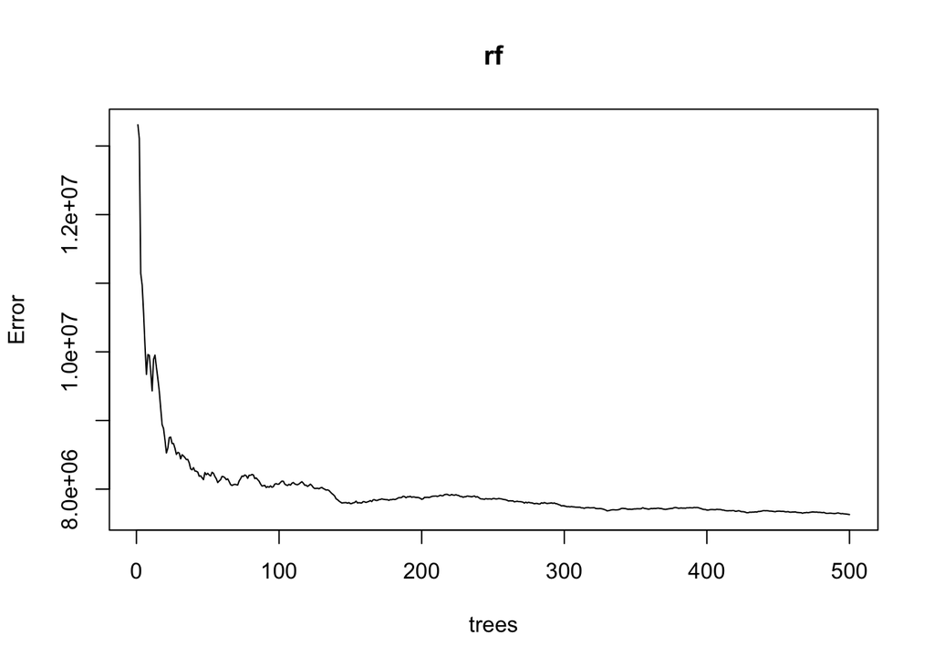

```r
plot(rf)
```

we can use the varImpPlot() function to create a plot that displays the importance of each predictor variable in the final model:

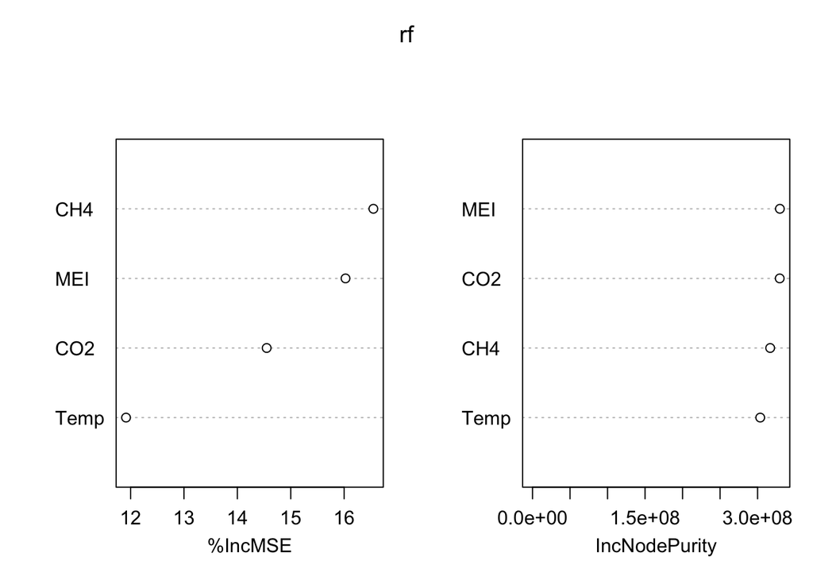

```r
varImpPlot(rf)
```

The x-axis displays the average increase in node purity and increase in mean squared error of the regression trees based on splitting on the various predictors displayed on the y-axis.

Predicting using test data

```r
predictions <- predict(rf,test[-5])
labels <- test$Freq

freq_values <- data.frame(actual=labels, predicted = predictions)
freq_values
```

|  | actual | predicted |
| --- | --- | --- |
| 1 | 4055 | 5978.750 |
| 10 | 7987 | 5895.069 |
| 13 | 2175 | 6654.761 |
| 15 | 3370 | 4243.969 |
| 16 | 1991 | 5841.415 |
| 37 | 1823 | 6504.811 |
| 38 | 3801 | 5315.033 |
| 45 | 5347 | 8103.918 |
| 46 | 8360 | 8122.341 |
| 55 | 10014 | 5268.706 |

[output cut: 41 more lines]

Mean Squared Error on test data is

```r
mean((freq_values$actual - freq_values$predicted)^2)
```

```
## [1] 9450565
```

Prediction of average fire size per month.

```r
rf_data <- train_data[-5]
#head(rf_data)

sample <- sample.int(n = nrow(rf_data),size = floor(.75*nrow(rf_data)),replace = F)
train <- rf_data[sample,]
test <- rf_data[-sample,]

rf <- randomForest(train$Average_Size~. ,data=train, importance = T, trControl = trControl)
print(rf)
```

```
##
## Call:
##  randomForest(formula = train$Average_Size ~ ., data = train,      importance = T, trControl = trControl)
##                Type of random forest: regression
##                      Number of trees: 500
## No. of variables tried at each split: 1
##
##           Mean of squared residuals: 3805.199
##                     % Var explained: 13.8
```

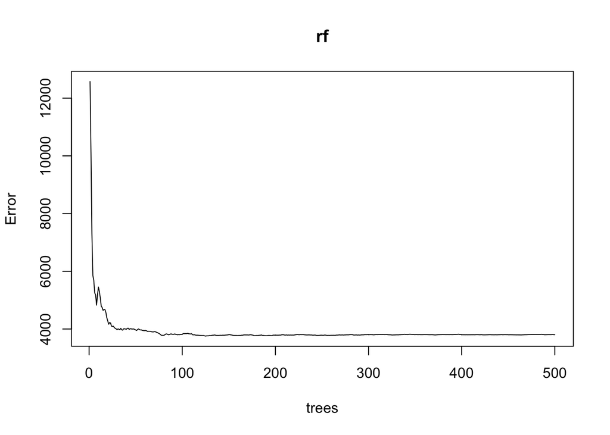

```r
plot(rf)
```

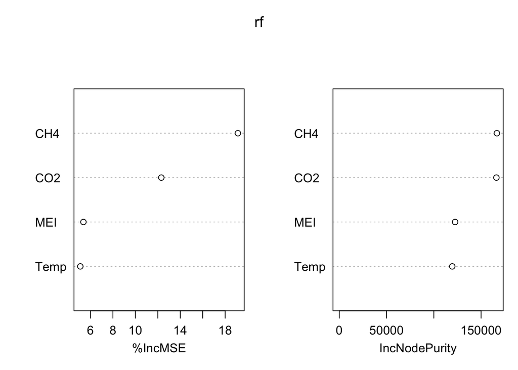

```r
varImpPlot(rf)
```

```r
predictions <- predict(rf,test[-5])
labels <- test$Average_Size

size_values <- data.frame(actual=labels, predicted = predictions)
size_values
```

|  | actual | predicted |
| --- | --- | --- |
| 5 | 12.450995 | 20.26801 |
| 9 | 41.639427 | 21.66631 |
| 14 | 46.508833 | 26.09520 |
| 15 | 14.150368 | 39.33812 |
| 20 | 56.757407 | 23.35782 |
| 21 | 63.807381 | 26.01755 |
| 23 | 21.937584 | 58.55043 |
| 26 | 17.228388 | 23.83418 |
| 27 | 21.110917 | 22.09429 |
| 33 | 137.611446 | 46.45290 |

[output cut: 41 more lines]

Mean Squared Error on test data is

```r
mean((size_values$actual - size_values$predicted)^2)
```

```
## [1] 16806.63
```

Hence we can say linear regression is succesful in predicting the regression values rather than decision trees and random forest in ur case